# Analisi Schede di Dimissioni Ospedaliere

### 1.5.2 GIORNATE DI DEGENZA

The following graph shows the *Giorni di Degenza* for each MDC and over the years of analysis.

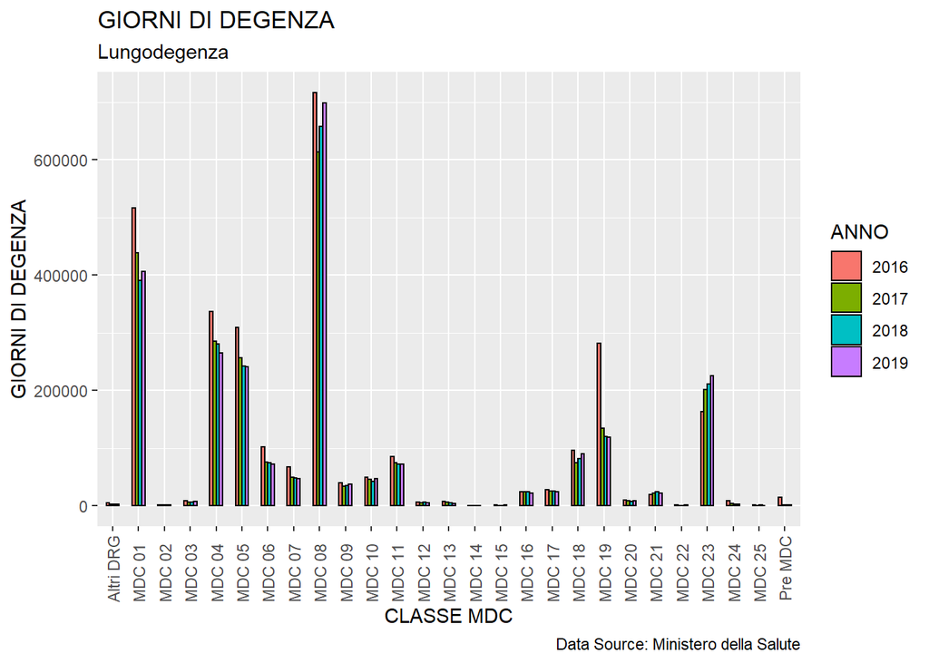

Table 1.5.4 provides a summary for *Giorni di Degenza* by MDC for each year.

|  | CLASSE_MDC | GIORNATE DI DEGENZA | ANNO |
| --- | --- | --- | --- |
| 1 | 01 - Malattie e disturbi del sistema nervoso | 515979 | 2016 |
| 2 | 02 - Malattie e disturbi dell'occhio | 1074 | 2016 |
| 3 | 03 - Malattie e disturbi dell'orecchio, del naso, della bocca e della gola | 8153 | 2016 |
| 4 | 04 - Malattie e disturbi dell'apparato respiratorio | 336221 | 2016 |
| 5 | 05 - Malattie e disturbi dell'apparato cardiocircolatorio | 309623 | 2016 |
| 6 | 06 - Malattie e disturbi dell'apparato digerente | 102299 | 2016 |
| 7 | 07 - Malattie e disturbi epatobiliari e del pancreas | 66520 | 2016 |
| 8 | 08 - Malattie e disturbi del sistema muscolo-scheletrico e del tessuto connettivo | 716440 | 2016 |
| 9 | 09 - Malattie e disturbi della pelle, del tessuto sottocutaneo e della mammella | 40070 | 2016 |
| 10 | 10 - Malattie e disturbi endocrini, nutrizionali e metabolici | 48918 | 2016 |

[output cut: 98 more lines]

The following graph shows the Mean value for *Giorni di Degenza* for each MDC.

#### 2019

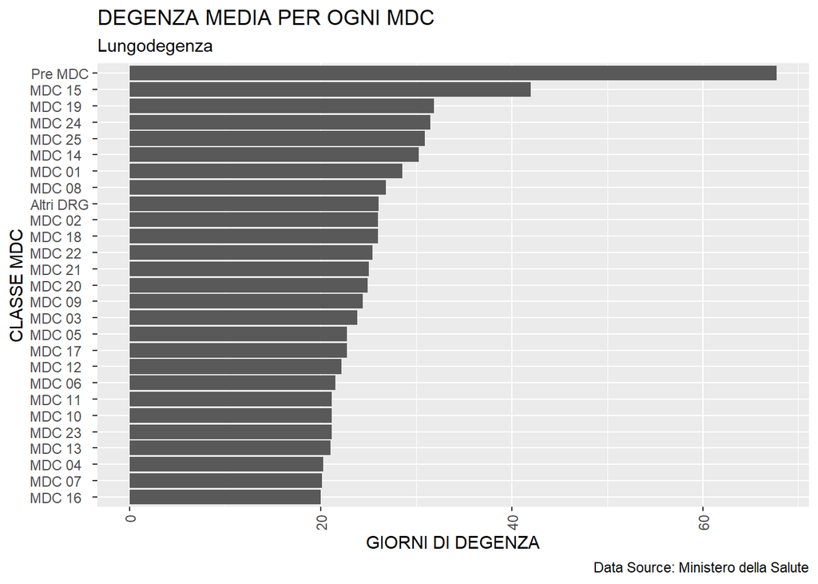

#### 2018

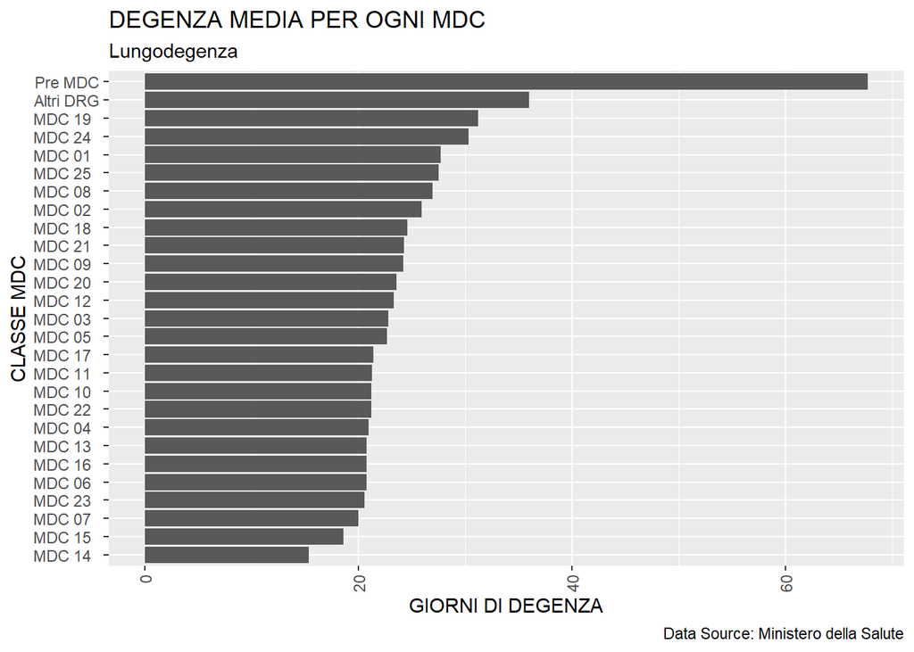

#### 2017

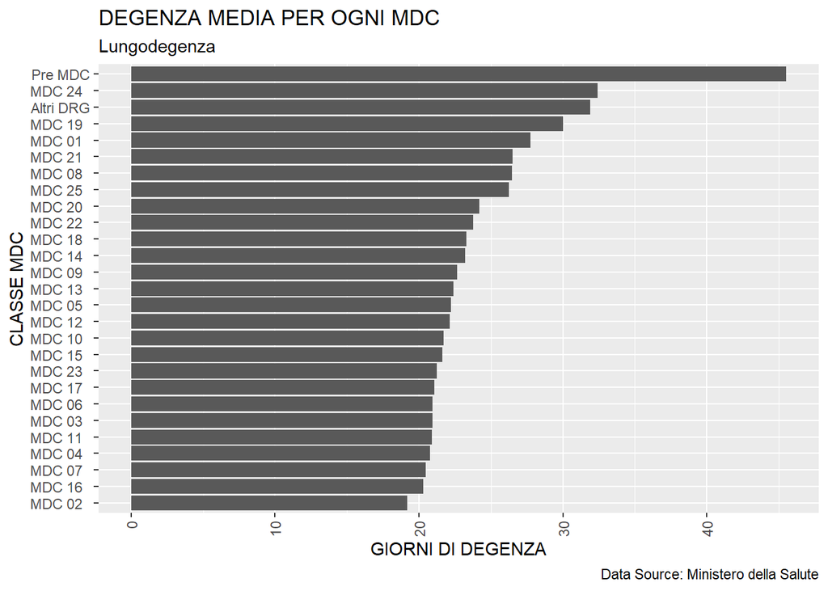

#### 2016

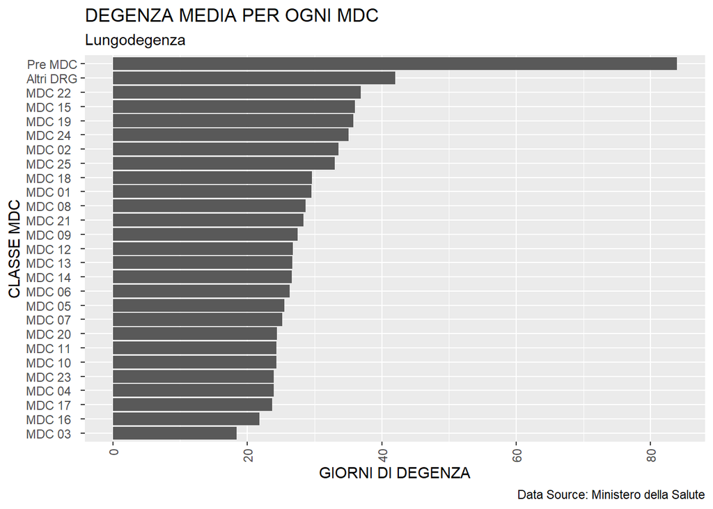

Table 1.5.4 provides a summary for the mean value for *“Giorni di Degenza”* for each MDC.

|  | CLASSE_MDC | DEGENZA MEDIA (giorni) | ANNO |
| --- | --- | --- | --- |
| 1 | 01 - Malattie e disturbi del sistema nervoso | 29.51 | 2016 |
| 2 | 02 - Malattie e disturbi dell'occhio | 33.562 | 2016 |
| 3 | 03 - Malattie e disturbi dell'orecchio, del naso, della bocca e della gola | 18.404 | 2016 |
| 4 | 04 - Malattie e disturbi dell'apparato respiratorio | 23.896 | 2016 |
| 5 | 05 - Malattie e disturbi dell'apparato cardiocircolatorio | 25.477 | 2016 |
| 6 | 06 - Malattie e disturbi dell'apparato digerente | 26.332 | 2016 |
| 7 | 07 - Malattie e disturbi epatobiliari e del pancreas | 25.187 | 2016 |
| 8 | 08 - Malattie e disturbi del sistema muscolo-scheletrico e del tessuto connettivo | 28.686 | 2016 |
| 9 | 09 - Malattie e disturbi della pelle, del tessuto sottocutaneo e della mammella | 27.464 | 2016 |
| 10 | 10 - Malattie e disturbi endocrini, nutrizionali e metabolici | 24.349 | 2016 |

[output cut: 98 more lines]

# 2 TASSI DI OSPEDALIZZAZIONE

## 2.1 Overview in Italia

### 2.1.1 TASSO DI OSPEDALIZZAZIONE IN ITALIA PER ATTIVITÀ

The following bar chart shows the evolution of the *Tasso di ospedalizzazione* in Italy in the period of analysis. As shown by the graph, there has been a decrease in the hospitalization rates per 1000 inhabitants, in particular for the activity *“Acuti - Regime ordinario”* (from 101.624 in 2016 to 97.611 in 2019).

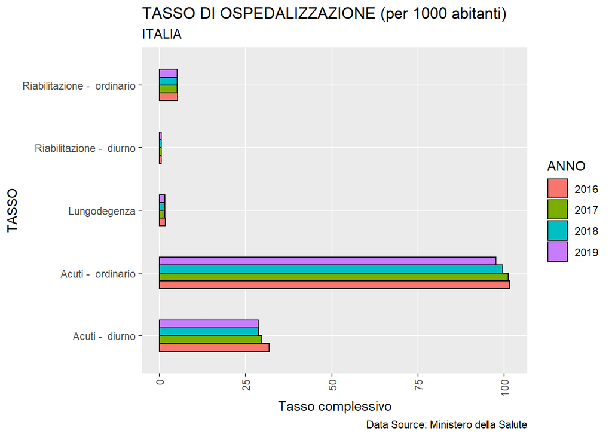

Table 2.1.1 provides an overview on the hospitalization rates (per 1000 inhabitants) in Italy during the period 2016-2019.

|  | ATTIVITÀ | Tasso complessivo Italia | ANNO |
| --- | --- | --- | --- |
| 1 | Acuti - Regime ordinario | 101.624 | 2016 |
| 2 | Acuti - Regime ordinario | 101.197 | 2017 |
| 3 | Acuti - Regime ordinario | 99.601 | 2018 |
| 4 | Acuti - Regime ordinario | 97.611 | 2019 |
| 5 | Acuti - Regime diurno | 31.829 | 2016 |
| 6 | Acuti - Regime diurno | 29.732 | 2017 |
| 7 | Acuti - Regime diurno | 28.856 | 2018 |
| 8 | Acuti - Regime diurno | 28.649 | 2019 |
| 9 | Riabilitazione - Regime ordinario | 5.232 | 2016 |
| 10 | Riabilitazione - Regime ordinario | 5.196 | 2017 |

[output cut: 10 more lines]

### 2.1.2 TASSI DI OSPEDALIZZAZIONE PER GENERE

The graph below shows the hospitalization rates in Italy per gender and for the different activities. In this case, there has been a small reduction for both gender and for all the activities.

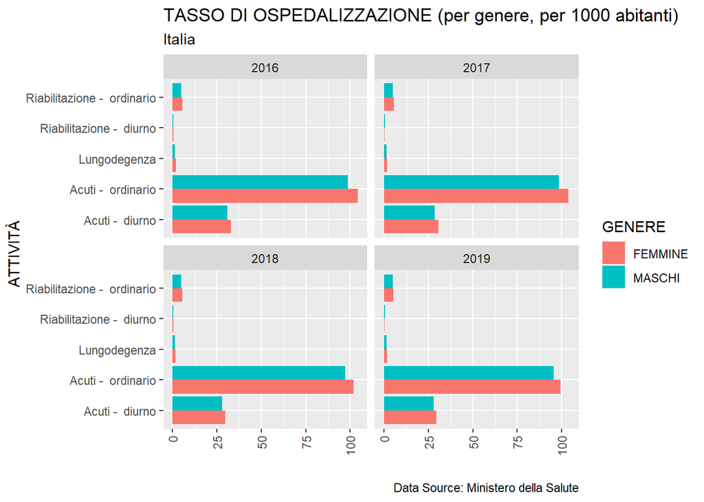

Table 2.1.2 provides a summary for the data about hospitalization rates by gender in Italy.

|  | Tasso osp. per 100 abitanti | ATTIVITÀ | ANNO | GENERE |
| --- | --- | --- | --- | --- |
| 1 | 98.69 | Acuti - Regime ordinario | 2016 | MASCHI |
| 2 | 30.771 | Acuti - Regime diurno | 2016 | MASCHI |
| 3 | 4.931 | Riabilitazione - Regime ordinario | 2016 | MASCHI |
| 4 | 0.646 | Riabilitazione - Regime diurno | 2016 | MASCHI |
| 5 | 1.483 | Lungodegenza | 2016 | MASCHI |
| 6 | 98.565 | Acuti - Regime ordinario | 2017 | MASCHI |
| 7 | 28.709 | Acuti - Regime diurno | 2017 | MASCHI |
| 8 | 4.92 | Riabilitazione - Regime ordinario | 2017 | MASCHI |
| 9 | 0.622 | Riabilitazione - Regime diurno | 2017 | MASCHI |
| 10 | 1.388 | Lungodegenza | 2017 | MASCHI |

[output cut: 30 more lines]

### 2.1.3 TASSO DI OSPEDALIZZAZIONE PER CATEGORIA DI ETÀ ED ATTIVITÀ

The following graph represents the evolution of the hospitalization rates by age category in Italy and for each activity.

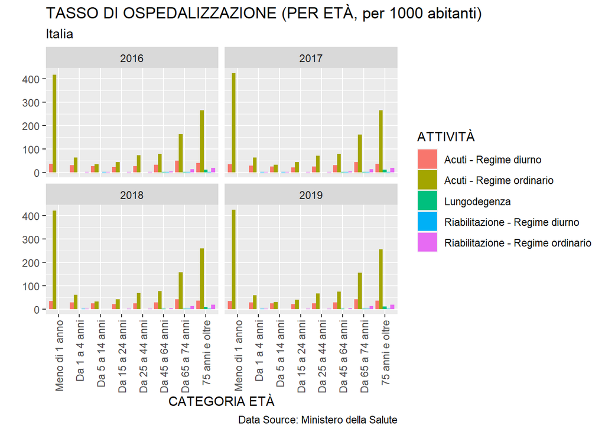

Table 2.1.3 provides the summary for the hospitalization rates in Italy by age category.

|  | Categoria età | TASSO | ANNO | ATTIVITÀ |
| --- | --- | --- | --- | --- |
| 1 | Meno di 1 anno | 416.965 | 2016 | Acuti - Regime ordinario |
| 2 | Da 1 a 4 anni | 62.149 | 2016 | Acuti - Regime ordinario |
| 3 | Da 5 a 14 anni | 33.218 | 2016 | Acuti - Regime ordinario |
| 4 | Da 15 a 24 anni | 44.382 | 2016 | Acuti - Regime ordinario |
| 5 | Da 25 a 44 anni | 72.361 | 2016 | Acuti - Regime ordinario |
| 6 | Da 45 a 64 anni | 78.967 | 2016 | Acuti - Regime ordinario |
| 7 | Da 65 a 74 anni | 162.185 | 2016 | Acuti - Regime ordinario |
| 8 | 75 anni e oltre | 265.323 | 2016 | Acuti - Regime ordinario |
| 9 | Meno di 1 anno | 424.813 | 2017 | Acuti - Regime ordinario |
| 10 | Da 1 a 4 anni | 62.211 | 2017 | Acuti - Regime ordinario |

[output cut: 150 more lines]

## 2.2 Acuti - Regime ordinario

Table 2.2.1 shows the hospitalization rates for the activity *Acuti - Regime ordinario* for the 4 years of analysis and the corresponding percentage variation. A 1.998% reduction in the hospitalization rates occurred between 2018 and 2019.

|  | TASSO | ANNO | ATTIVITÀ | VARIAZIONE % |
| --- | --- | --- | --- | --- |
| 1 | 101.624 | 2016 | Acuti - Regime ordinario |  |
| 2 | 101.197 | 2017 | Acuti - Regime ordinario | -0.42 |
| 3 | 99.601 | 2018 | Acuti - Regime ordinario | -1.577 |
| 4 | 97.611 | 2019 | Acuti - Regime ordinario | -1.998 |

### 2.2.1 TASSO PER CATEGORIE DI ETÀ

As shown by the graph, through the years of analysis the hospitalization rates by age category have a little drop for the activity *Acuti - Regime ordinario*.

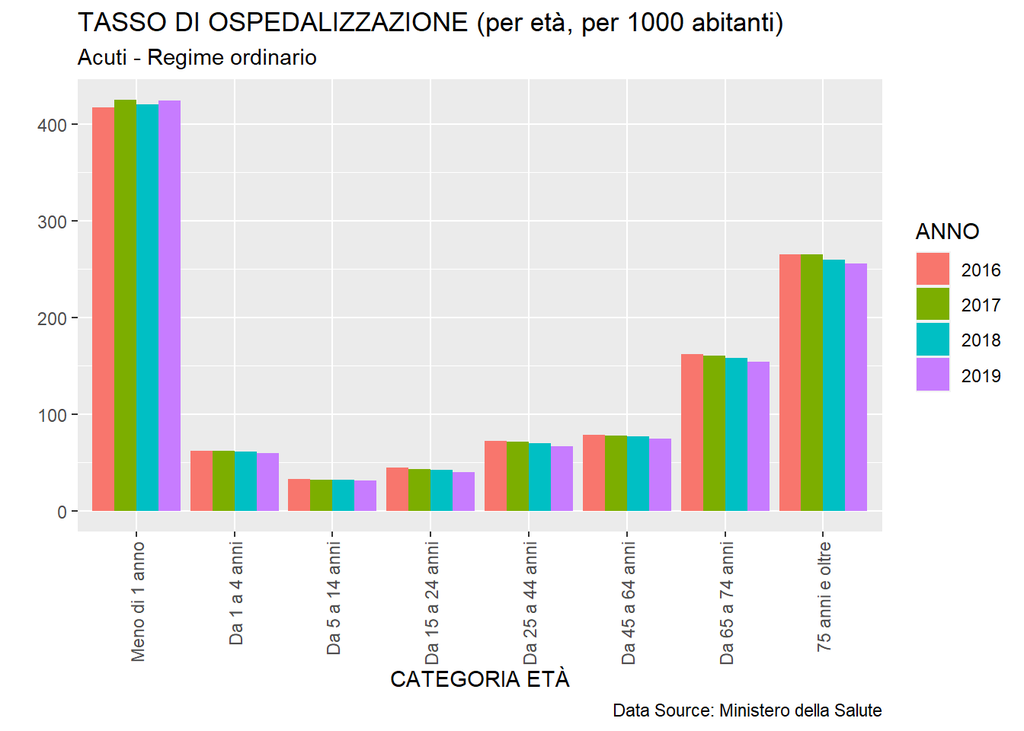

Table 2.2.2 represents the data about hospitalization rates for age category in *Acuti - Regime ordinario* for each year.

|  | Categoria età | Tasso di ospedalizz. (per 1000 ab.) | ANNO |
| --- | --- | --- | --- |
| 1 | Meno di 1 anno | 416.965 | 2016 |
| 2 | Da 1 a 4 anni | 62.149 | 2016 |
| 3 | Da 5 a 14 anni | 33.218 | 2016 |
| 4 | Da 15 a 24 anni | 44.382 | 2016 |
| 5 | Da 25 a 44 anni | 72.361 | 2016 |
| 6 | Da 45 a 64 anni | 78.967 | 2016 |
| 7 | Da 65 a 74 anni | 162.185 | 2016 |
| 8 | 75 anni e oltre | 265.323 | 2016 |
| 9 | Meno di 1 anno | 424.813 | 2017 |
| 10 | Da 1 a 4 anni | 62.211 | 2017 |

[output cut: 22 more lines]

### 2.2.2 TASSO PER REGIONE E SESSO

The following graphs show the evolution of the hospitalization rate in Italy by region and gender in the period 2016-2019. The horizontal blue line displays the hospitalization rates in all Italy for the male gender, the red one for the female gender.

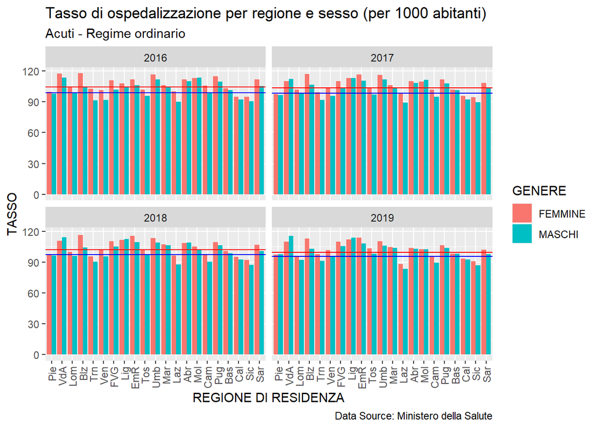

Table 2.2.3 shows the hospitalization rate for each region, by gender and year, for the activity *Acuti - Regime ordinario*.

|  | REGIONE DI RESIDENZA | Tasso osp. Maschi | Tasso osp. Femmine | ANNO |
| --- | --- | --- | --- | --- |
| 1 | Piemonte | 97.744 | 99.684 | 2016 |
| 2 | Valle d'Aosta | 113.653 | 117.466 | 2016 |
| 3 | Lombardia | 99.034 | 103.906 | 2016 |
| 4 | P.A. Bolzano | 104.671 | 117.791 | 2016 |
| 5 | P.A. Trento | 91.541 | 102.527 | 2016 |
| 6 | Veneto | 92.023 | 101.24 | 2016 |
| 7 | Friuli V.G. | 101.922 | 110.858 | 2016 |
| 8 | Liguria | 104.074 | 107.777 | 2016 |
| 9 | Emilia Romagna | 106.18 | 112.009 | 2016 |
| 10 | Toscana | 95.905 | 101.895 | 2016 |

[output cut: 78 more lines]

### 2.2.3 TASSO PER TIPO DRG

The following section shows the evolution of the hospitalization rates per 1000 inhabitants for the activity *Acuti - Regime ordinario* by **DRG** type. Indeed, the type of DRG could be *“C”*, that stands for **“CHIRURGICI”**, or *“M”*, that means **“MEDICI O NON CLASSIFICABILI”**. The distiction between the two is that the first DRG is characterised by the presence of surgery or other “significant” procedure, while the second one considers DRG with diagnostic or therapeutic procedures with no need of operating room. As shown by the graph, the incidence of DRG type “M” is higher. For example, in 2019 there has been around 56 discharges per 1000 inhabitants for DRG with diagnostic or therapeutic procedures with no need of operating room(type “M”), while the incidence for the discharges characterized by DRG that required surgery(type “C”) is around 44 discharges per 1000 inhabitants in the same year.

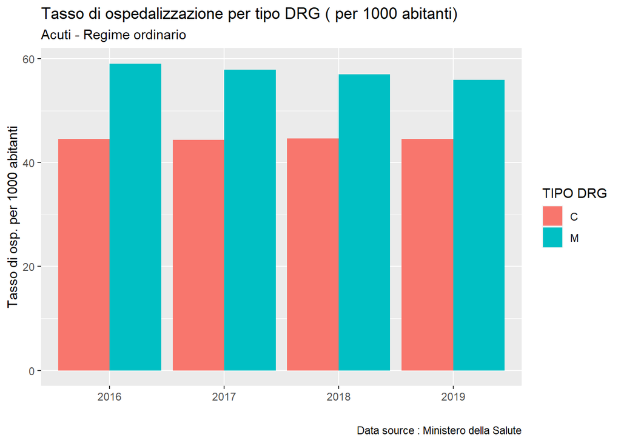

The table below shows in detail the hospitalization rates previously discusssed and represented.

|  | Tasso di osp. per 1000 abitanti | TIPO DRG | Anno |
| --- | --- | --- | --- |
| 1 | 44.5613 | C | 2016 |
| 2 | 44.4146 | C | 2017 |
| 3 | 44.6157 | C | 2018 |
| 4 | 44.5376 | C | 2019 |
| 5 | 59.0671 | M | 2016 |
| 6 | 57.8873 | M | 2017 |
| 7 | 57.0141 | M | 2018 |
| 8 | 55.9236 | M | 2019 |

## 2.3 Acuti - Regime diurno

Table 3.1.1 shows the hospitalization rates for the activity *Acuti - Regime diurno* for the 4 years of analysis and the corresponding percentage variation. An important decrease occurred in between 2016 and 2017 (-6.588%). The rate is decreasing over the 4 years of analysis.

|  | TASSO | ANNO | ATTIVITÀ | VARIAZIONE % |
| --- | --- | --- | --- | --- |
| 1 | 31.829 | 2016 | Acuti - Regime diurno |  |
| 2 | 29.732 | 2017 | Acuti - Regime diurno | -6.588 |
| 3 | 28.856 | 2018 | Acuti - Regime diurno | -2.946 |
| 4 | 28.649 | 2019 | Acuti - Regime diurno | -0.717 |

### 2.3.1 TASSO PER CATEGORIE DI ETÀ

The graph below shows that through the years of analysis the hospitalization rates by age category is decreased for all the age categories for the activity *Acuti - Regime diurno*.

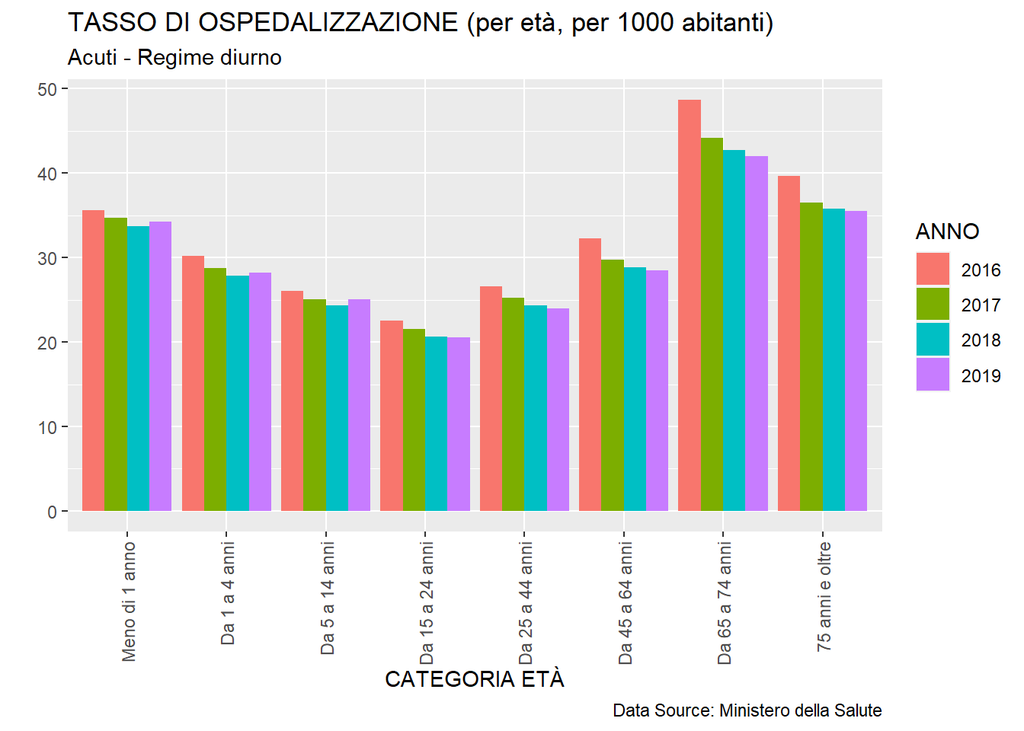

Table 3.1.2 represents the data about hospitalization rates for age category in *Acuti - Regime diurno* for each year.

|  | Categoria età | Tasso di ospedalizz. (per 1000 ab.) | ANNO |
| --- | --- | --- | --- |
| 1 | Meno di 1 anno | 35.635 | 2016 |
| 2 | Da 1 a 4 anni | 30.159 | 2016 |
| 3 | Da 5 a 14 anni | 26.051 | 2016 |
| 4 | Da 15 a 24 anni | 22.507 | 2016 |
| 5 | Da 25 a 44 anni | 26.609 | 2016 |
| 6 | Da 45 a 64 anni | 32.269 | 2016 |
| 7 | Da 65 a 74 anni | 48.658 | 2016 |
| 8 | 75 anni e oltre | 39.713 | 2016 |
| 9 | Meno di 1 anno | 34.671 | 2017 |
| 10 | Da 1 a 4 anni | 28.796 | 2017 |

[output cut: 22 more lines]

### 2.3.2 TASSO PER REGIONE E SESSO

The following graphs show the evolution of the hospitalization rate in Italy by region and gender in the period 2016-2019. The horizontal blue line displays the hospitalization rates in Italy for the male gender, the red one for the female gender.

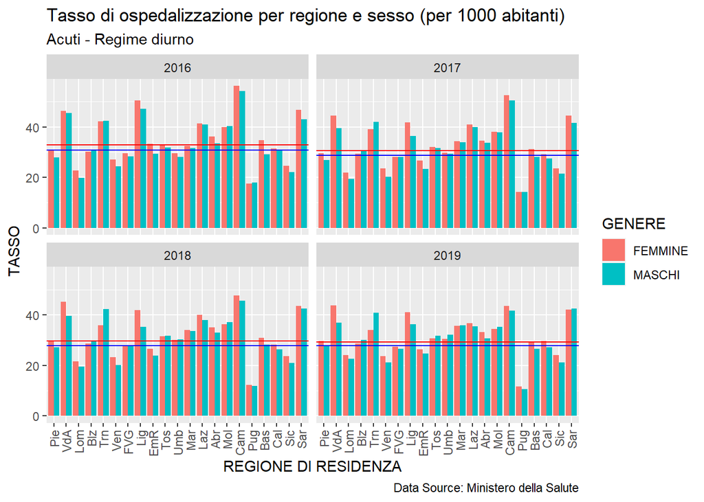

Table 3.1.3 shows the hospitalization rate for each region, by gender and year, for the activity *Acuti - Regime diurno*.

|  | REGIONE DI RESIDENZA | Tasso osp. Maschi | Tasso osp. Femmine | ANNO |
| --- | --- | --- | --- | --- |
| 1 | Piemonte | 27.828 | 30.534 | 2016 |
| 2 | Valle d'Aosta | 45.564 | 46.275 | 2016 |
| 3 | Lombardia | 19.757 | 22.673 | 2016 |
| 4 | P.A. Bolzano | 30.909 | 30.162 | 2016 |
| 5 | P.A. Trento | 42.519 | 42.284 | 2016 |
| 6 | Veneto | 24.467 | 27.017 | 2016 |
| 7 | Friuli V.G. | 28.429 | 29.505 | 2016 |
| 8 | Liguria | 47.195 | 50.425 | 2016 |
| 9 | Emilia Romagna | 29.41 | 33.299 | 2016 |
| 10 | Toscana | 31.768 | 32.7 | 2016 |

[output cut: 78 more lines]

### 2.3.3 TASSO PER TIPO DRG

The following section shows the evolution of the hospitalization rates per 1000 inhabitants for the activity *Acuti - Regime diurno* by DRG type. In this activity, the incidence of DRG type “C” is higher. For example, in 2019 there has been around 17 discharges per 1000 inhabitants for DRG that required surgery (type “C”) while dischages of DRG with diagnostic or therapeutic procedures with no need of operating room(type “M”) have been around 12 per 1000 inhabitants in the same year.

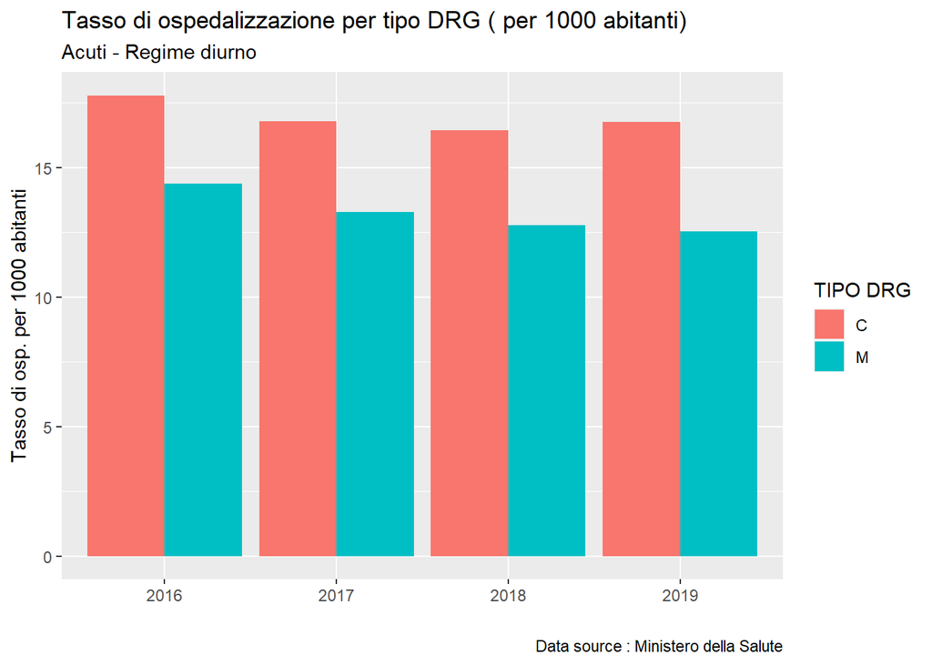

The table below shows in detail the hospitalization rates previously discusssed and represented.

|  | Tasso di osp. per 1000 abitanti | TIPO DRG | Anno |
| --- | --- | --- | --- |
| 1 | 17.7882 | C | 2016 |
| 2 | 16.7785 | C | 2017 |
| 3 | 16.4376 | C | 2018 |
| 4 | 16.7586 | C | 2019 |
| 5 | 14.381 | M | 2016 |
| 6 | 13.2706 | M | 2017 |
| 7 | 12.7748 | M | 2018 |
| 8 | 12.521 | M | 2019 |

## 2.4 Riabilitazione - Regime ordinario

Table 4.1.1 shows the hospitalization rates for the activity *Riabilitazione - Regime ordinario* for the 4 years of analysis and the corresponding percentage variation. The hospitalization rate is decreasing over time.

|  | TASSO | ANNO | ATTIVITÀ | VARIAZIONE % |
| --- | --- | --- | --- | --- |
| 1 | 5.232 | 2016 | Riabilitazione - Regime ordinario |  |
| 2 | 5.196 | 2017 | Riabilitazione - Regime ordinario | -0.688 |
| 3 | 5.144 | 2018 | Riabilitazione - Regime ordinario | -1.001 |
| 4 | 5.144 | 2019 | Riabilitazione - Regime ordinario | 0 |

### 2.4.1 TASSO PER CATEGORIE DI ETÀ

As shown by the graph, through the years of analysis the hospitalization rates remained stable for some of the age categories, while decreased for others, in particular for the categories: *“Da 65 a 74 anni”* and *“75 anni e oltre”* for the activity *Riabilitazione - Regime ordinario*.

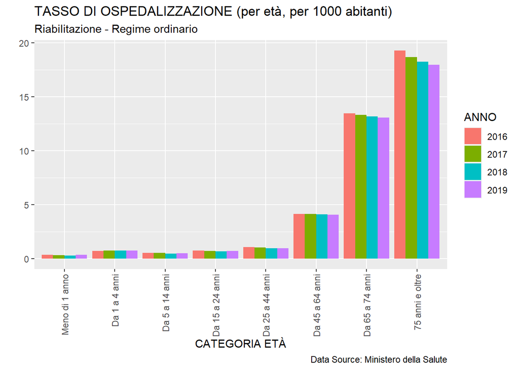

Table 4.1.2 represents the data about hospitalization rates for age category in *Riabilitazione - Regime ordinario* for each year.

|  | Categoria età | Tasso di ospedalizz. (per 1000 ab.) | ANNO |
| --- | --- | --- | --- |
| 1 | Meno di 1 anno | 0.34 | 2016 |
| 2 | Da 1 a 4 anni | 0.713 | 2016 |
| 3 | Da 5 a 14 anni | 0.514 | 2016 |
| 4 | Da 15 a 24 anni | 0.727 | 2016 |
| 5 | Da 25 a 44 anni | 1.061 | 2016 |
| 6 | Da 45 a 64 anni | 4.144 | 2016 |
| 7 | Da 65 a 74 anni | 13.464 | 2016 |
| 8 | 75 anni e oltre | 19.266 | 2016 |
| 9 | Meno di 1 anno | 0.321 | 2017 |
| 10 | Da 1 a 4 anni | 0.739 | 2017 |

[output cut: 22 more lines]

### 2.4.2 TASSO PER REGIONE E SESSO

The following graphs show the evolution of the hospitalization rate in Italy by region and gender in the period 2016-2019. The horizontal blue line displays the hospitalization rates in Italy for the male gender, the red one for the female gender.

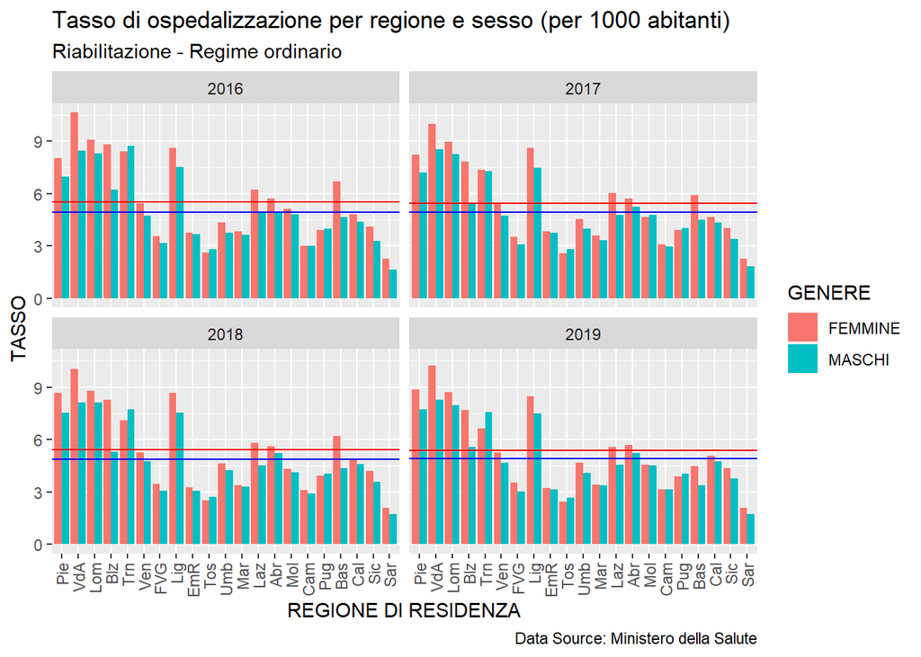

Table 4.1.3 shows the hospitalization rate for each region, by gender and year, for the activity *Riabilitazione - Regime ordinario*.

|  | REGIONE DI RESIDENZA | Tasso osp. Maschi | Tasso osp. Femmine | ANNO |
| --- | --- | --- | --- | --- |
| 1 | Piemonte | 6.969 | 8.018 | 2016 |
| 2 | Valle d'Aosta | 8.453 | 10.641 | 2016 |
| 3 | Lombardia | 8.317 | 9.085 | 2016 |
| 4 | P.A. Bolzano | 6.204 | 8.828 | 2016 |
| 5 | P.A. Trento | 8.729 | 8.405 | 2016 |
| 6 | Veneto | 4.749 | 5.432 | 2016 |
| 7 | Friuli V.G. | 3.145 | 3.574 | 2016 |
| 8 | Liguria | 7.5 | 8.602 | 2016 |
| 9 | Emilia Romagna | 3.674 | 3.748 | 2016 |
| 10 | Toscana | 2.819 | 2.618 | 2016 |

[output cut: 78 more lines]

## 2.5 Riabilitazione - Regime diurno

Table 5.1.1 shows the hospitalization rates for the activity *Riabilitazione - Regime diurno* for the 4 years of analysis and the corresponding percentage variation. An important reduction in the hospitalization rate is occurred in between 2017 an 2018 (-6.986%). The rate is decreasing until 2018, then there has been a little increase.

|  | TASSO | ANNO | ATTIVITÀ | VARIAZIONE % |
| --- | --- | --- | --- | --- |
| 1 | 0.525 | 2016 | Riabilitazione - Regime diurno |  |
| 2 | 0.501 | 2017 | Riabilitazione - Regime diurno | -4.571 |
| 3 | 0.466 | 2018 | Riabilitazione - Regime diurno | -6.986 |
| 4 | 0.47 | 2019 | Riabilitazione - Regime diurno | 0.858 |

### 2.5.1 TASSO PER CATEGORIE DI ETÀ

As shown by the graph, through the years of analysis the hospitalization rates is increased for some of the age categories (*“Da 1 a 4 anni”* and *“Da 5 a 14 anni”*) and it is decreased for some others (*“Da 45 a 64 anni”*; *“Da 65 a 74 anni”* and *“75 anni e oltre”* ) for the activity *Riabilitazione - Regime diurno*.

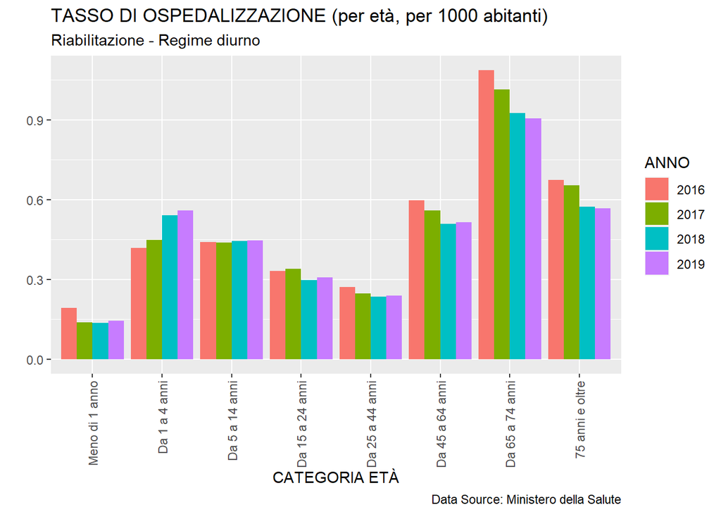

Table 5.1.2 represents the data about hospitalization rates for age category in *Riabilitazione - Regime diurno* for each year.

|  | Categoria età | Tasso di ospedalizz. (per 1000 ab.) | ANNO |
| --- | --- | --- | --- |
| 1 | Meno di 1 anno | 0.194 | 2016 |
| 2 | Da 1 a 4 anni | 0.418 | 2016 |
| 3 | Da 5 a 14 anni | 0.441 | 2016 |
| 4 | Da 15 a 24 anni | 0.331 | 2016 |
| 5 | Da 25 a 44 anni | 0.272 | 2016 |
| 6 | Da 45 a 64 anni | 0.599 | 2016 |
| 7 | Da 65 a 74 anni | 1.086 | 2016 |
| 8 | 75 anni e oltre | 0.673 | 2016 |
| 9 | Meno di 1 anno | 0.139 | 2017 |
| 10 | Da 1 a 4 anni | 0.449 | 2017 |

[output cut: 22 more lines]

### 2.5.2 TASSO PER REGIONE E SESSO

The following graphs show the evolution of the hospitalization rate in Italy by region and gender in the period 2016-2019. The horizontal blue line displays the hospitalization rates in Italy for the male gender, the red one for the female gender.

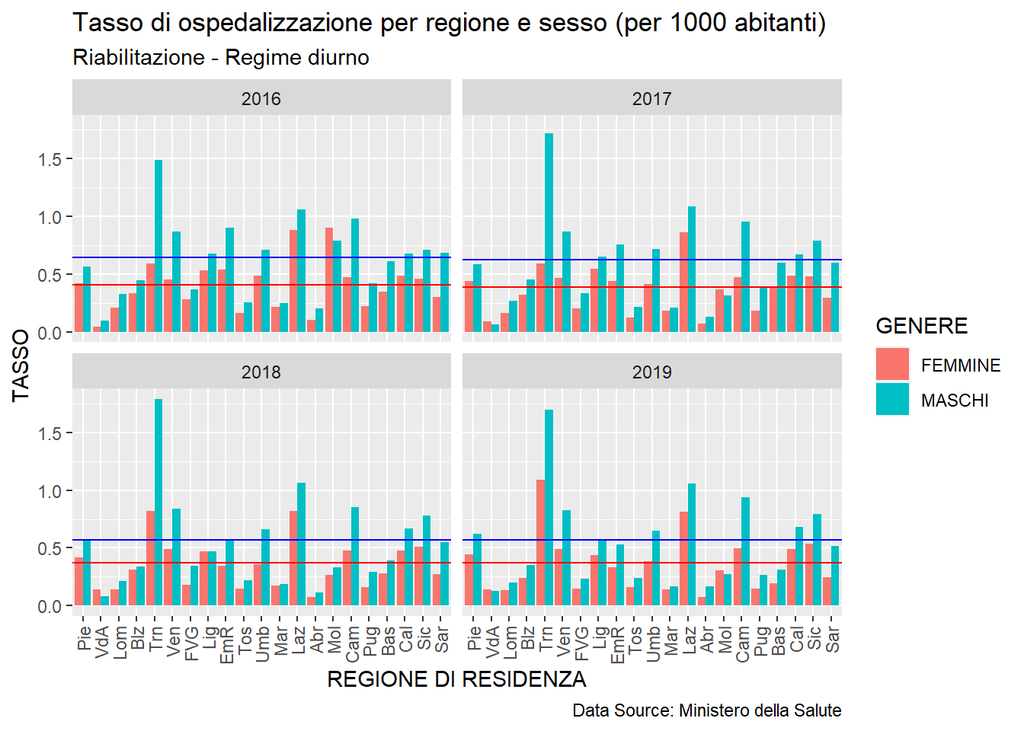

Table 5.1.3 shows the hospitalization rate for each region, by gender and year, for the activity *Riabilitazione - Regime diurno*.

|  | REGIONE DI RESIDENZA | Tasso osp. Maschi | Tasso osp. Femmine | ANNO |
| --- | --- | --- | --- | --- |
| 1 | Piemonte | 0.563 | 0.419 | 2016 |
| 2 | Valle d'Aosta | 0.097 | 0.046 | 2016 |
| 3 | Lombardia | 0.329 | 0.209 | 2016 |
| 4 | P.A. Bolzano | 0.448 | 0.337 | 2016 |
| 5 | P.A. Trento | 1.489 | 0.593 | 2016 |
| 6 | Veneto | 0.87 | 0.451 | 2016 |
| 7 | Friuli V.G. | 0.367 | 0.279 | 2016 |
| 8 | Liguria | 0.68 | 0.529 | 2016 |
| 9 | Emilia Romagna | 0.903 | 0.537 | 2016 |
| 10 | Toscana | 0.258 | 0.161 | 2016 |

[output cut: 78 more lines]

## 2.6 Lungodegenza

Table 6.1.1 shows the hospitalization rates for the activity *Lungodegenza* for the 4 years of analysis and the corresponding percentage variation. A huge decrease occurred between 2016 and 2017 (-5.306%).

|  | TASSO | ANNO | ATTIVITÀ | VARIAZIONE % |
| --- | --- | --- | --- | --- |
| 1 | 1.715 | 2016 | Lungodegenza |  |
| 2 | 1.624 | 2017 | Lungodegenza | -5.306 |
| 3 | 1.598 | 2018 | Lungodegenza | -1.601 |
| 4 | 1.624 | 2019 | Lungodegenza | 1.627 |

### 2.6.1 TASSO PER CATEGORIE DI ETÀ

The graph below shows that the hospitalization rate is almost 0 for the earlier age categories and is much higher for the last ones. Through the years of analysis the hospitalization rates decreased for these latter categories for the activity *Lungodegenza*.

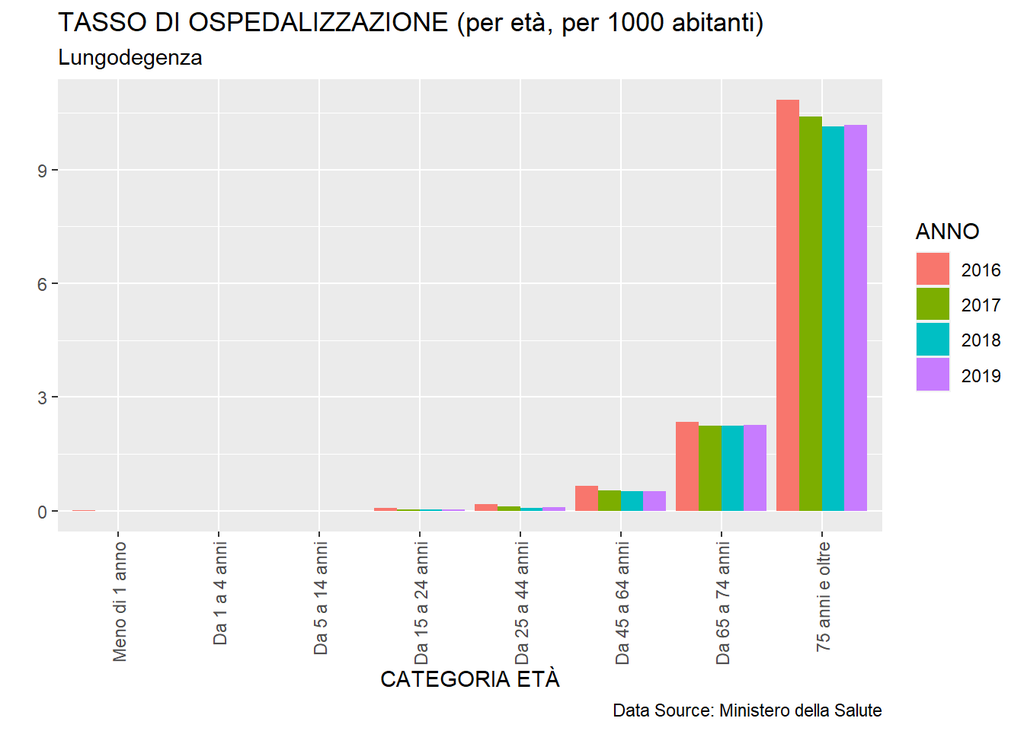

Table 6.1.2 represents the data about hopspitalization rates for age category in *Lungodegenza* for each year.

|  | Categoria età | Tasso di ospedalizz. (per 1000 ab.) | ANNO |
| --- | --- | --- | --- |
| 1 | Meno di 1 anno | 0.01 | 2016 |
| 2 | Da 1 a 4 anni | 0 | 2016 |
| 3 | Da 5 a 14 anni | 0.001 | 2016 |
| 4 | Da 15 a 24 anni | 0.072 | 2016 |
| 5 | Da 25 a 44 anni | 0.18 | 2016 |
| 6 | Da 45 a 64 anni | 0.654 | 2016 |
| 7 | Da 65 a 74 anni | 2.352 | 2016 |
| 8 | 75 anni e oltre | 10.837 | 2016 |
| 9 | Meno di 1 anno | 0.002 | 2017 |
| 10 | Da 1 a 4 anni | 0 | 2017 |

[output cut: 22 more lines]

### 2.6.2 TASSO PER REGIONE E SESSO

The following graphs show the evolution of the hospitalization rate in Italy by region and gender in the period 2016-2019. The horizontal blue line displays the hospitalization rates in Italy for the male gender, the red one for the female gender.

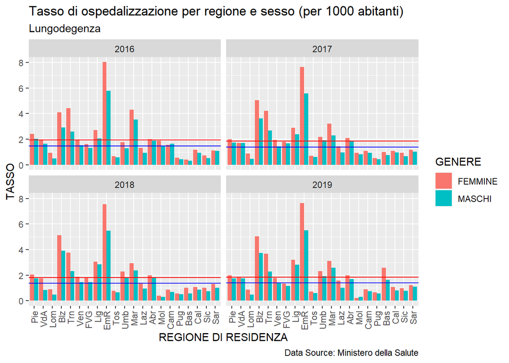

Table 6.1.3 shows the hospitalization rate for each region, by gender and year, for the activity *Lungodegenza*.

|  | REGIONE DI RESIDENZA | Tasso osp. Maschi | Tasso osp. Femmine | ANNO |
| --- | --- | --- | --- | --- |
| 1 | Piemonte | 2.03 | 2.401 | 2016 |
| 2 | Valle d'Aosta | 1.658 | 1.978 | 2016 |
| 3 | Lombardia | 0.481 | 0.924 | 2016 |
| 4 | P.A. Bolzano | 2.931 | 4.103 | 2016 |
| 5 | P.A. Trento | 2.59 | 4.412 | 2016 |
| 6 | Veneto | 1.521 | 1.938 | 2016 |
| 7 | Friuli V.G. | 1.312 | 1.608 | 2016 |
| 8 | Liguria | 2.07 | 2.703 | 2016 |
| 9 | Emilia Romagna | 5.773 | 8.02 | 2016 |
| 10 | Toscana | 0.571 | 0.657 | 2016 |

[output cut: 78 more lines]

# 3 CONFRONTO TASSI OSPEDALIZZAZIONE: ITALIA vs INGHILTERRA

## 3.1 Popolazione: Italia vs Inghilterra

This first part shows the differences between English and Italian population in 2019, considering age category and gender. Data about population are provided by [**Istat**](http://dati.istat.it/Index.aspx?DataSetCode=DCIS_POPRES1) for Italy and [**UK Office for National Statistics**](https://www.ons.gov.uk/peoplepopulationandcommunity/populationandmigration/populationestimates/bulletins/annualmidyearpopulationestimates/latest#ageing) for England. Note that for this latter, the population used in computing the surgical incidences is the one of 2012.

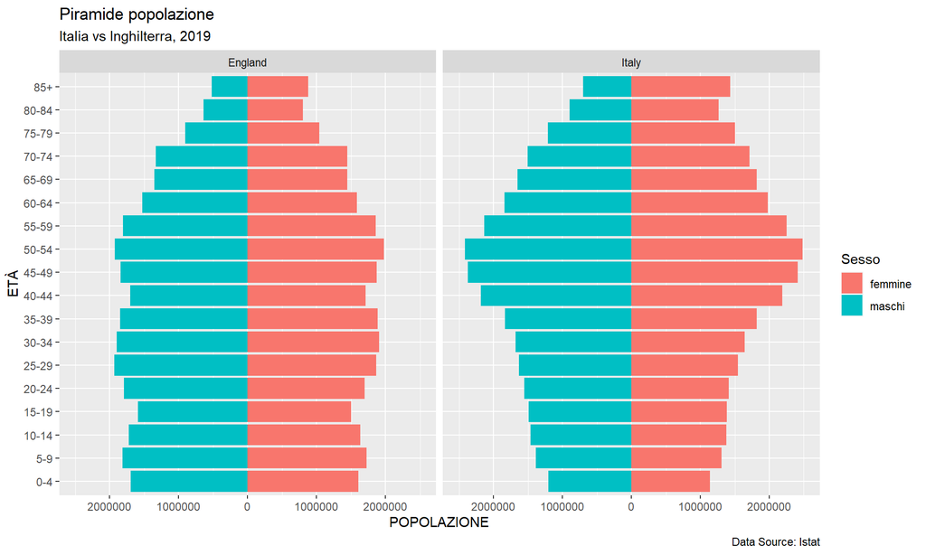

Table 3.1.1 summarises the data about the italian and english population in 2019, by age category and gender. The total population is 59.816.673, where 29.131.195 are male and 30.685.478 female. In England the total population in 2019 is 56.286.961, where 27.827.831 are male and 28.459.130 female.

|  | Età | popolazione | Sesso | Categoria_età | Country |
| --- | --- | --- | --- | --- | --- |
| 1 | 0 | 221685 | maschi | 0-4 | Italy |
| 2 | 0 | 209322 | femmine | 0-4 | Italy |
| 3 | 1 | 234386 | maschi | 0-4 | Italy |
| 4 | 1 | 221360 | femmine | 0-4 | Italy |
| 5 | 2 | 241671 | maschi | 0-4 | Italy |
| 6 | 2 | 229142 | femmine | 0-4 | Italy |
| 7 | 3 | 234791 | femmine | 0-4 | Italy |
| 8 | 3 | 248155 | maschi | 0-4 | Italy |
| 9 | 4 | 256257 | maschi | 0-4 | Italy |
| 10 | 4 | 241983 | femmine | 0-4 | Italy |

[output cut: 374 more lines]

## 3.2 Numero di interventi e tassi di ospedalizzazione in Inghilterra per categoria di età.

The data collected for England about hospitalization rate consider two main activities, **In-patient surgeries** and **Out-patient surgeries**. The difference between the two is that the first one requires overnight hospitalization, while patients receiving out-patient care don’t need to spend a night in a hospital. These two activities can be compared respectively to the italian **Ricovero Ordinario** and **Day-hospital**.

The following graph shows the total number of surgeries in England (In-patient and Out-patient) by age category and gender.

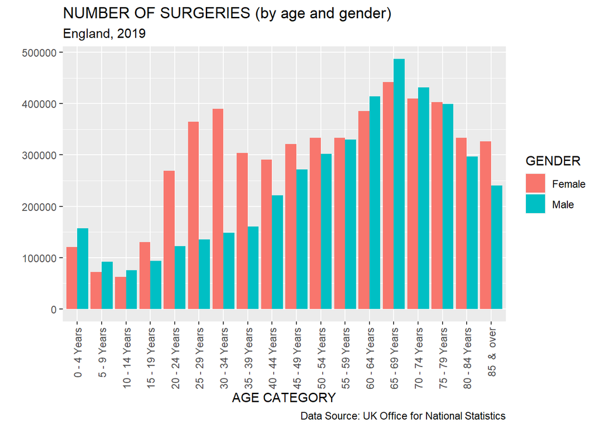

Table 3.1.2 summarises the data of the graph above.

|  | AGE CATEGORY | Number of Surgeries | GENDER |
| --- | --- | --- | --- |
| 1 | 0 - 4 Years | 157318 | Male |
| 2 | 5 - 9 Years | 91701 | Male |
| 3 | 10 - 14 Years | 75166 | Male |
| 4 | 15 - 19 Years | 93711 | Male |
| 5 | 20 - 24 Years | 122099 | Male |
| 6 | 25 - 29 Years | 135322 | Male |
| 7 | 30 - 34 Years | 148168 | Male |
| 8 | 35 - 39 Years | 160424 | Male |
| 9 | 40 - 44 Years | 221674 | Male |
| 10 | 45 - 49 Years | 271452 | Male |

[output cut: 26 more lines]

The following graph shows the the hospitalization rate in England for age category and gender, considering both In-patients and out-patients surgeries.

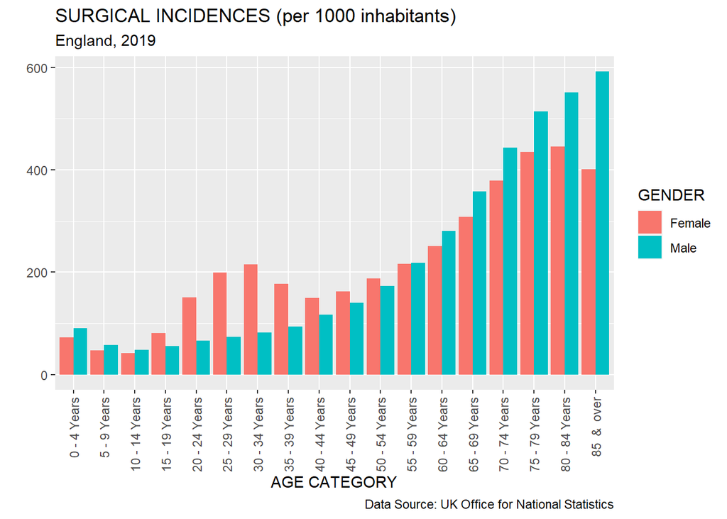

Table 3.1.3 shows the data about surgical incidences represented in the graph above

|  | AGE CATEGORY | Incidence | GENDER |
| --- | --- | --- | --- |
| 1 | 0 - 4 Years | 90.574 | Male |
| 2 | 5 - 9 Years | 58.094 | Male |
| 3 | 10 - 14 Years | 48.816 | Male |
| 4 | 15 - 19 Years | 55.595 | Male |
| 5 | 20 - 24 Years | 66.597 | Male |
| 6 | 25 - 29 Years | 74.125 | Male |
| 7 | 30 - 34 Years | 82.407 | Male |
| 8 | 35 - 39 Years | 93.969 | Male |
| 9 | 40 - 44 Years | 116.584 | Male |
| 10 | 45 - 49 Years | 139.967 | Male |

[output cut: 26 more lines]

## 3.3 Tassi di ospedalizzazione: Inghilterra vs Italia

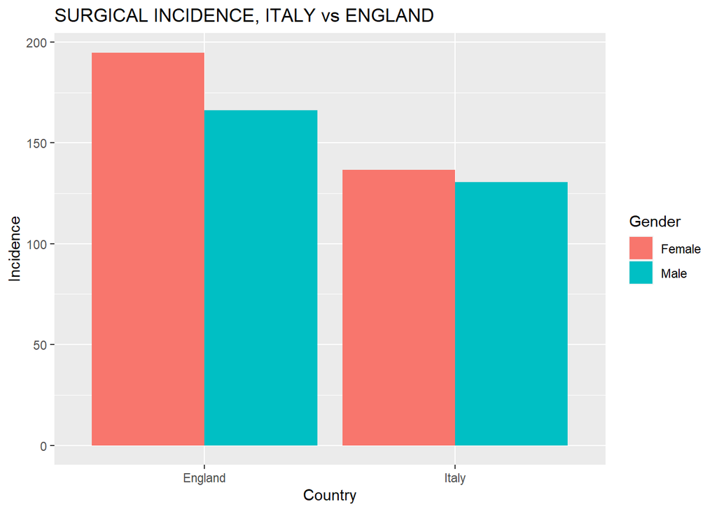

Table 3.1.4 shows the data about hospitalization rate represented in the bar chart above.

|  | Incidence | Gender | Country |
| --- | --- | --- | --- |
| 1 | 130.559 | Male | Italy |
| 2 | 136.756 | Female | Italy |
| 3 | 166.239 | Male | England |
| 4 | 194.833 | Female | England |

# 4 CONFRONTO DATI DIMISSIONI OSPEDALIERE: ISTAT VS MINISTERO DELLA SALUTE

The following section provides a comparison between the data about hospitalization discharges in 2019 collected from two different sources: Istat and Italian Ministry of Health.

Istat provided data just for the activity *Acuti*, distinguishing between *“Ordinario”* and *“Day-Hospital”*, that are respectively given by *Acuti - Regime ordinario* and *Acuti - Regime diurno* from Ministry of Health.

|  | attività | DIMISSIONI | Source | ANNO |
| --- | --- | --- | --- | --- |
| 1 | Acuti - Regime ordinario | 6020466 | Ministero della Salute | 2019 |
| 2 | Acuti - Regime diurno | 1751585 | Ministero della Salute | 2019 |
| 3 | Acuti - Regime diurno | 1753874 | Istat | 2019 |
| 4 | Acuti - Regime ordinario | 6010269 | Istat | 2019 |

As shown by the table above, there is a slight difference in the data provided by the two sources for both *Regime ordinario* and *Regime diurno*.

## 4.1 Istat, Acuti - Regime ordinario

This part focuses on the analysis of hospitalization discharges for the activity *“Acuti - Regime ordinario”* considering data provided by istat. In the data provided by istat, the age categories are a very limited number compared to the ones of Italian Ministry. This is shown in the graph below.

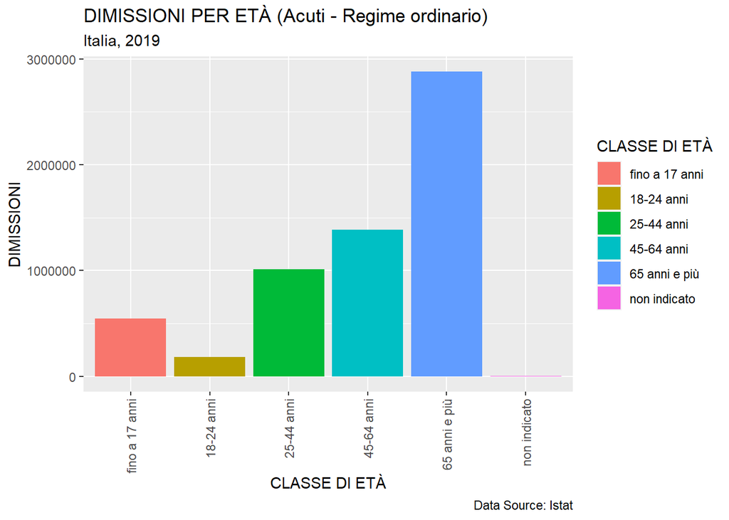

Table 4.1.2 provides a summary of the hospitalization discharges by age category in 2019 in Italy.

|  | REGIME DI RICOVERO | CLASSE DI ETÀ | DIMISSIONI |
| --- | --- | --- | --- |
| 1 | Acuti - Regime ordinario | fino a 17 anni | 545331 |
| 2 | Acuti - Regime ordinario | 18-24 anni | 184902 |
| 3 | Acuti - Regime ordinario | 25-44 anni | 1014090 |
| 4 | Acuti - Regime ordinario | 45-64 anni | 1385435 |
| 5 | Acuti - Regime ordinario | 65 anni e più | 2877885 |
| 6 | Acuti - Regime ordinario | non indicato | 2626 |

Data provided by Istat consider the distinction between hospitalization discharges by gender, as well as data provided by Italian Ministry of Health. As shown by the graph below, the numbers are slightly different due to the fact that the Italian Ministry data, in distinguishing between male and female, does not consider discharges where age or gender were not well specified.

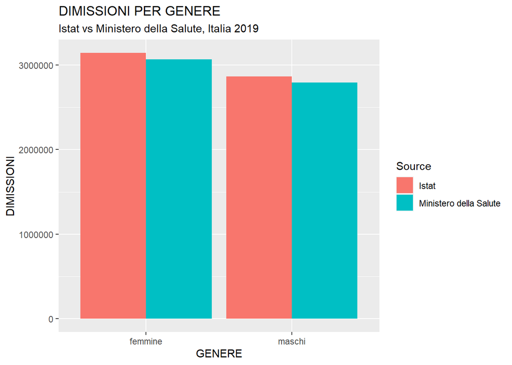

An important difference in data provided by istat is the distinction between country of origin of the patient, as shown in the graph below.

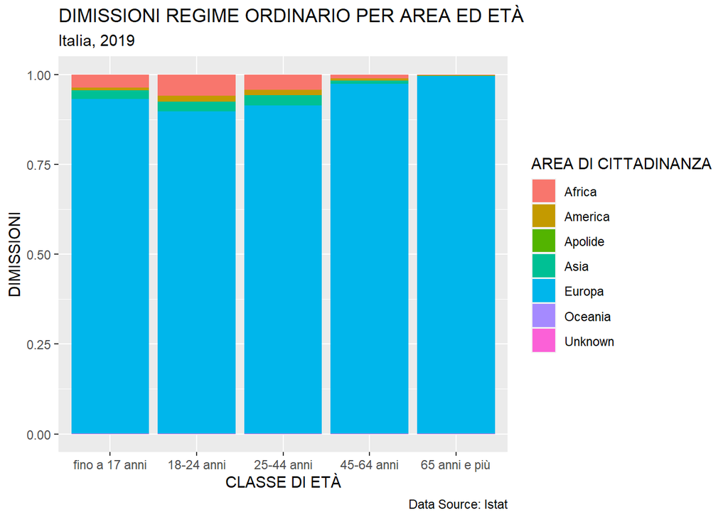

The pie chart below shows the geographical area of the patient without discriminate by age category. As shown, the discharges of people from *Oceania* and people that are stateless (*Apolide*) are negligible. The most important proportion of the table is, of course, by patients of Europe. This is due to the fact that the number of discharges of Italian people is the highest, namely 5.615.223.

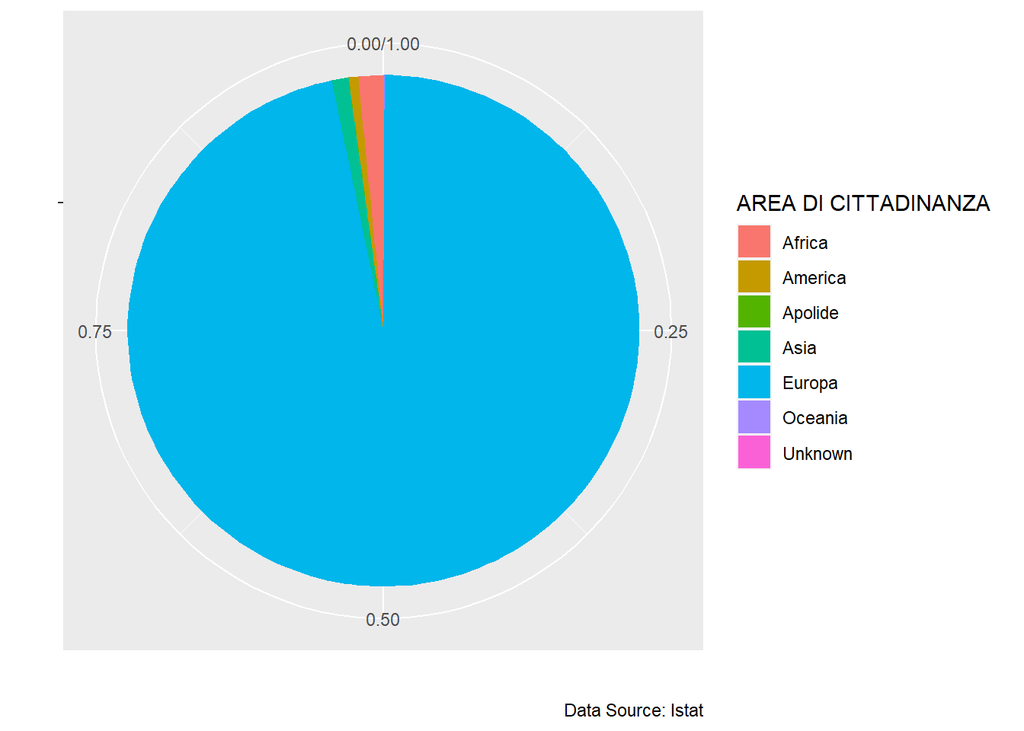

The following table summarises the data shown in the graphs above.

|  | REGIME DI RICOVERO | GENERE | CLASSE DI ETÀ | AREA DI CITTADINANZA | ANNO | DIMISSIONI |
| --- | --- | --- | --- | --- | --- | --- |
| 1 | Acuti - Regime ordinario | totale | fino a 17 anni | Africa | 2019 | 19777 |
| 2 | Acuti - Regime ordinario | totale | fino a 17 anni | America | 2019 | 4504 |
| 3 | Acuti - Regime ordinario | totale | fino a 17 anni | Asia | 2019 | 12757 |
| 4 | Acuti - Regime ordinario | totale | fino a 17 anni | Europa | 2019 | 507805 |
| 5 | Acuti - Regime ordinario | totale | fino a 17 anni | Oceania | 2019 | 50 |
| 6 | Acuti - Regime ordinario | totale | fino a 17 anni | Unknown | 2019 | 227 |
| 7 | Acuti - Regime ordinario | totale | fino a 17 anni | Apolide | 2019 | 211 |
| 8 | Acuti - Regime ordinario | totale | 18-24 anni | Africa | 2019 | 10893 |
| 9 | Acuti - Regime ordinario | totale | 18-24 anni | America | 2019 | 3085 |
| 10 | Acuti - Regime ordinario | totale | 18-24 anni | Asia | 2019 | 5016 |

[output cut: 25 more lines]

## 4.2 Istat, Acuti - Regime diurno

This second part is concerned to the analysis of hospitalization discharges for the activity *“Acuti - Regime diurno”* considering data provided by istat.

This first graph shows the hospitalization discharges taking into account the different age category.

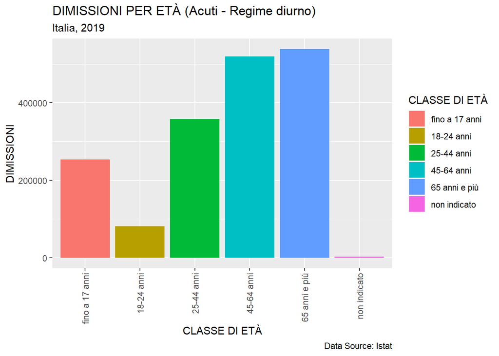

Table 4.1.4 provides a summary of the hospitalization discharges by age category in 2019 in Italy.

|  | REGIME DI RICOVERO | CLASSE DI ETÀ | DIMISSIONI |
| --- | --- | --- | --- |
| 1 | Acuti - Regime diurno | fino a 17 anni | 253557 |
| 2 | Acuti - Regime diurno | 18-24 anni | 81513 |
| 3 | Acuti - Regime diurno | 25-44 anni | 358298 |
| 4 | Acuti - Regime diurno | 45-64 anni | 519739 |
| 5 | Acuti - Regime diurno | 65 anni e più | 538404 |
| 6 | Acuti - Regime diurno | non indicato | 2363 |

Data provided by Istat consider the distinction between hospitalization discharges by gender, as well as data provided by Italian Ministry of Health. Even in the case of *Acuti - Regime diurno* the numbers are slightly different due to the fact that the Italian Ministry data, in distinguishing between male and female, does not consider discharges where age or gender were not well specified.

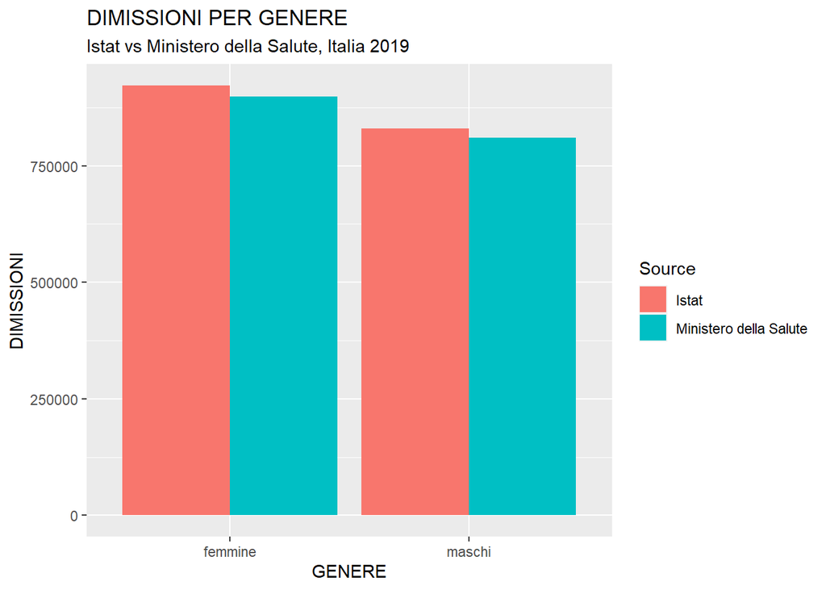

An important difference in data provided by istat is the distinction between country of origin of the patient, as shown in the graph below.

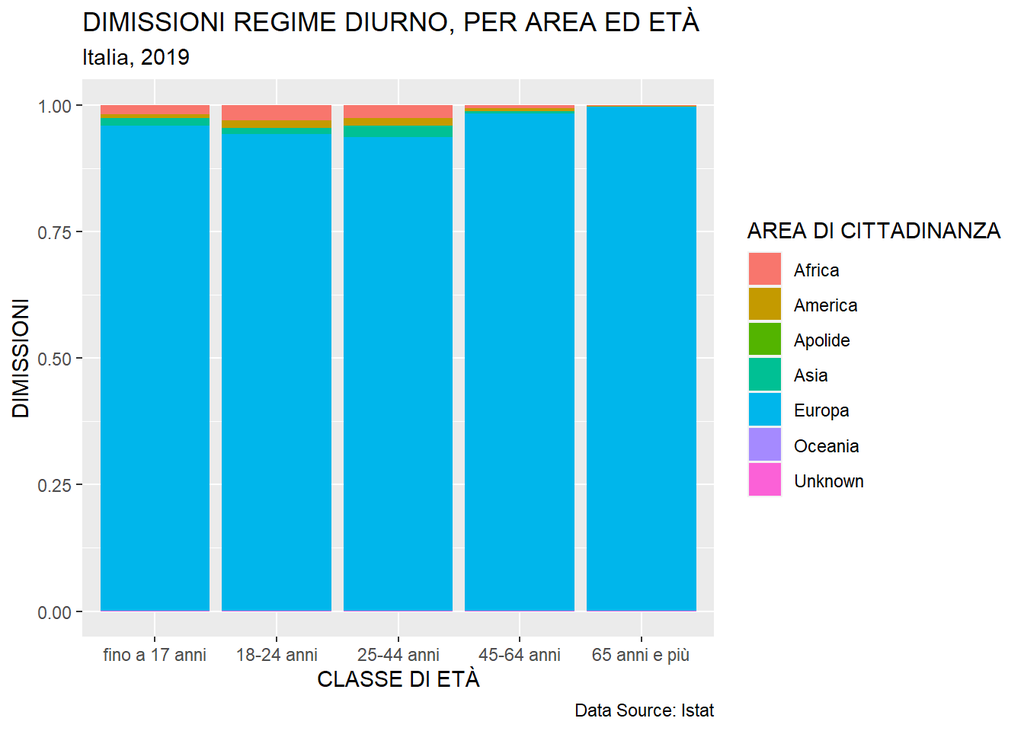

The pie chart below shows the geographical area of the patient without discriminate by age category for *Acuti - Regime diurno*. Even in this case, the discharges of people from *Oceania* and people that are stateless (*Apolide*) are negligible. The most important proportion of the table is, of course, by patients of Europe. This is due to the fact that the number of discharges of Italian people is the highest, that is 1.647.029.

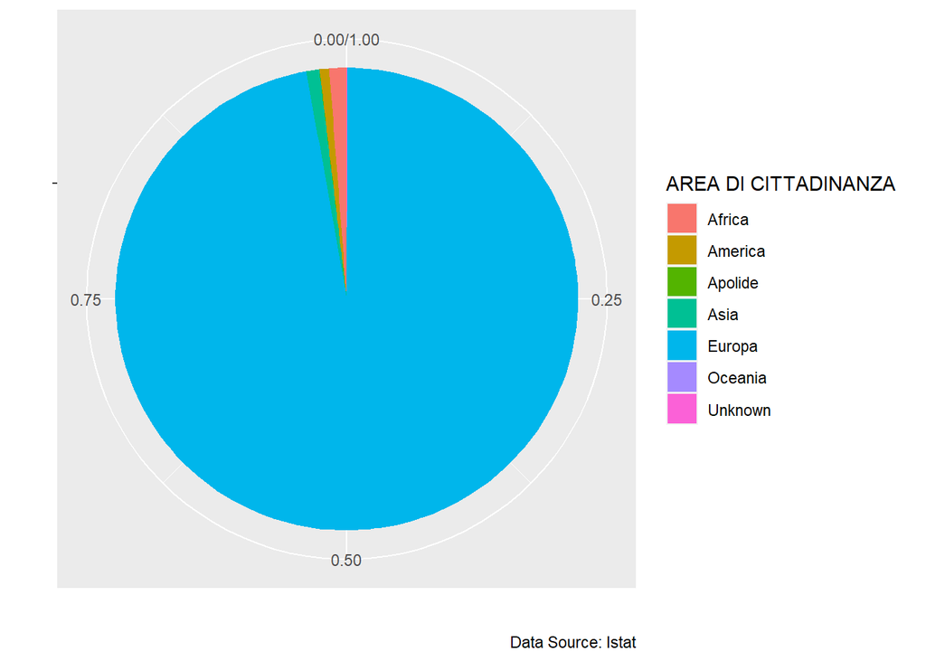

The following table summarises the data shown in the graphs above.

|  | REGIME DI RICOVERO | GENERE | CLASSE DI ETÀ | AREA DI CITTADINANZA | ANNO | DIMISSIONI |
| --- | --- | --- | --- | --- | --- | --- |
| 1 | Acuti - Regime diurno | totale | fino a 17 anni | Africa | 2019 | 4902 |
| 2 | Acuti - Regime diurno | totale | fino a 17 anni | America | 2019 | 1706 |
| 3 | Acuti - Regime diurno | totale | fino a 17 anni | Asia | 2019 | 3705 |
| 4 | Acuti - Regime diurno | totale | fino a 17 anni | Europa | 2019 | 243101 |
| 5 | Acuti - Regime diurno | totale | fino a 17 anni | Oceania | 2019 | 14 |
| 6 | Acuti - Regime diurno | totale | fino a 17 anni | Unknown | 2019 | 67 |
| 7 | Acuti - Regime diurno | totale | fino a 17 anni | Apolide | 2019 | 62 |
| 8 | Acuti - Regime diurno | totale | 18-24 anni | Africa | 2019 | 2471 |
| 9 | Acuti - Regime diurno | totale | 18-24 anni | America | 2019 | 1206 |
| 10 | Acuti - Regime diurno | totale | 18-24 anni | Asia | 2019 | 1038 |

[output cut: 25 more lines]

## 4.3 Tasso di ospedalizzazione per l’attività Acuti: dati Istat vs Ministero della Salute

The following paragraph focuses on the differences in the overall hospitalization rate considering the two different data sources (Istat and Ministero della Salute) in Italy in 2019 for the activity *Acuti*, so, considering the sum of discharges in *Regime ordinario* and *Regime diurno*.

This table shows the hospitalization rates per 1000 inhabitants(Italy, 2019), considering the two different data sources, for the activity *Acuti* (taking into account of the discharges in *Regime ordinario* and *Regime diurno*). As shown, the difference is particularly small. Indeed, the number of disharges is almost the same in considering the two sources.

[output not shown]

# GLOSSARIO

**Accessi**: presence in hospital without overnight stay, for the provision of day-hospital benefits. The number of Accessi refers to the number of days where the patient went to the facility to receive the service. Indeed, in case of day-hospital regime, every single daily access for the entire treatment period is counted as *giornata di degenza* and the date of discharge corresponds to the date of the last contact with the institution.

**Attività**: type of hospital care; it includes: *ricoveri per acuti*, *riabilitazione* and *lungodegenza*.

**Day Hospital (diurno)**: characterized by: programmed hospitalization; it is limited to part of the day, it does not include overnight staying; it provides multiprofessional or plurispecialistic services that require a running time that deviates sharply from that necessary for a normal outpatient performance.

**DRG – DIAGNOSIS RELATED GROUP**: category of hospital admissions defined in such a way that they have similar clinical characteristics and require homogeneous volumes of hospital resources for their treatment. The following information is required to assign each admission episode to a specific DRG: the main diagnosis of discharge, all secondary diagnoses, all surgical procedures and the main diagnostic and therapeutic procedures, age, sex and mode of discharge. The attribution is carried out using an algorithm that analyzes the above information and determines the group to which it belongs.

**Giorno di Degenza**: period of 24 hours during which a bed is occupied.

**MDC - MAJOR DIAGNOSTIC CATEGORY (MDC)**: the DRG system provides a higher level of grouping based on a criterion of clinical relevance (anatomical or etiological): based on the main diagnosis reported in the *Scheda di Dimissione Ospedaliera*, the MDC category is assigned; subsequently, a specific DRG is assigned among those belonging to the selected MDC.

**Ricoveri di Lungodegenza**: these are the admissions of patients discharged from departments belonging to the *LUNGODEGENTI* discipline.

**Regime di ricovero**: distinguishes between “RICOVERO ORDINARIO”, that requires for overnight stay in the hospital, and “RICOVERO IN DAY HOSPITAL”,characterized by the presence in hospital just for a part of the day.

**Ricoveri per Acuti**: all cases of discharges from departments other than those classified as rehabilitative or long-term; healthy infants are also excluded.

**Ricoveri di Riabilitazione**: identified as admissions of patients discharged from departments belonging to the disciplines: *UNITA’ SPINALE*, *RECUPERO E RIABILITAZIONE FUNZIONALE*, *NEURORIABILITAZIONE*, and hospitalization in rehabilitation institutions only (LUNGODEGENZA excluded).

**Ricovero Ordinario**: provides for the allocation of a bed and the continuous stay of the patient with overnight stay in the hospital.

**Tasso di ospedalizzazione**: the hospitalization rate provides a summary measure on the use of hospitalization of the population under study. It is calculated as the ratio of the number of hospitalizations, everywhere carried out, relating to persons resident in a given region, and the total population resident there.

**Valore Soglia**: value of stay duration, specific for each DRG, above or below which a stay in *Regime ordinario* is considered “abnormal for the duration of the stay”.